# Project 3 Group 2

Michelle Mondy

October 19, 2017

# Overview

For this project, we will use data to answer the question “What are the most valued data science skills?” For our approach, we have decided to scrape data from both Cybercoders and Indeed job listings to see which skills are most sought after when looking to hire a Data Scientist.

## Load Required Packages

```r
library(rvest)
library(stringr)
library(RMySQL)
library(tidyr)
library(dplyr)
```

## Grab data from Indeed

In order to scrape data from Indeed, we identified tags using the SelectorGadget. We decided to use the the first 10 pages of job listings results assuming they would be the most relevant.

```r
getData <- function(url){
IndeedJobTitle<-url %>%
  read_html() %>%
  html_nodes("#resultsCol .jobtitle") %>%
  html_text()
IndeedJobTitle_clean <<- str_extract(IndeedJobTitle, "[[:alpha:]., /-]{2,}")

IndeedJobLocation<-url %>%
  read_html() %>%
  html_nodes(".location") %>%
  html_text()
IndeedJobLocation_clean <<- str_extract(IndeedJobLocation, "[[:alpha:], ]{2,}")

IndeedSkills<-url %>%
  read_html() %>%
  html_nodes(".experience") %>%
  html_text()
IndeedSkills_clean <<- str_extract(str_sub(IndeedSkills, start=22), "[[:alpha:], ]{2,}")
}

getData("https://www.indeed.com/jobs?q=data+scientist&l=")
page1 <- data.frame(IndeedJobTitle_clean,IndeedJobLocation_clean,IndeedSkills_clean)
getData("https://www.indeed.com/jobs?q=Data+Scientist&start=10")
page2 <- data.frame(IndeedJobTitle_clean,IndeedJobLocation_clean,IndeedSkills_clean)
getData("https://www.indeed.com/jobs?q=Data+Scientist&start=20")
page3 <- data.frame(IndeedJobTitle_clean,IndeedJobLocation_clean,IndeedSkills_clean)
getData("https://www.indeed.com/jobs?q=Data+Scientist&start=30")
page4 <- data.frame(IndeedJobTitle_clean,IndeedJobLocation_clean,IndeedSkills_clean)
getData("https://www.indeed.com/jobs?q=Data+Scientist&start=40")
page5 <- data.frame(IndeedJobTitle_clean,IndeedJobLocation_clean,IndeedSkills_clean)
getData("https://www.indeed.com/jobs?q=Data+Scientist&start=50")
#page6 <- data.frame(IndeedJobTitle_clean,IndeedJobLocation_clean,IndeedSkills_clean)
getData("https://www.indeed.com/jobs?q=Data+Scientist&start=60")
page7 <- data.frame(IndeedJobTitle_clean,IndeedJobLocation_clean,IndeedSkills_clean)
getData("https://www.indeed.com/jobs?q=Data+Scientist&start=70")
page8 <- data.frame(IndeedJobTitle_clean,IndeedJobLocation_clean,IndeedSkills_clean)
getData("https://www.indeed.com/jobs?q=Data+Scientist&start=80")
page9 <- data.frame(IndeedJobTitle_clean,IndeedJobLocation_clean,IndeedSkills_clean)
getData("https://www.indeed.com/jobs?q=Data+Scientist&start=90")
page10 <- data.frame(IndeedJobTitle_clean,IndeedJobLocation_clean,IndeedSkills_clean)


indeed_data <- rbind(page1, page2, page3, page4, page5, page7, page8, page9, page10)
```

## Creating the MySQL tables

To follow the same structure as Umais, I have created the following 2 tables in MySQL. Note: The password will need to be updated in the connection statement.

```r
mydb = dbConnect(MySQL(), user='root', password='sqlpass', dbname='project3', host='localhost')

dbGetQuery(mydb, "DROP TABLE IF EXISTS IndeedDataScienceJobs;" )
```

```
## data frame with 0 columns and 0 rows
```

```r
dbGetQuery(mydb, "DROP TABLE IF exists IndeedDataScienceSkills;" )
```

```
## data frame with 0 columns and 0 rows
```

```r
dbGetQuery(mydb, "CREATE TABLE IndeedDataScienceJobs(
  JobId int auto_increment primary key,
  JobTitle nvarchar(255),
  JobLocation nvarchar(255)
  );" )
```

```
## data frame with 0 columns and 0 rows
```

```r
dbGetQuery(mydb, "CREATE TABLE IndeedDataScienceSkills(
  SkillId int auto_increment primary key,
  JobId int,
  SkillName nvarchar(255)
  );" )
```

```
## data frame with 0 columns and 0 rows
```

## Transforming the Data to make it more usable

Since we have the data in a data frame, but it is not very usuable yet, we would like to insert it into a separate tables in MYSQL and use sql to transform it. Once the data is in the format that fits the tables created above, it will be insert into those tables.

```r
dbWriteTable(mydb, "indeed_data", indeed_data, overwrite = TRUE)
```

```
## [1] TRUE
```

```r
#This query creates a separate field (skill1-12) for each of the skills listed in the "IndeedSkills_clean" column. It also strips out the white space.

trans_query <-
"SELECT
IndeedJobTitle_clean
,IndeedJobLocation_clean
,case when
substring_index ( substring_index ( IndeedSkills_clean,',',12 ), ',', -1) <> substring_index ( substring_index ( IndeedSkills_clean,',',11 ), ',', -1)
then trim(substring_index ( substring_index ( IndeedSkills_clean,',',12 ), ',', -1)) else null
end as skill12
,case when
substring_index ( substring_index ( IndeedSkills_clean,',',11 ), ',', -1) <> substring_index ( substring_index ( IndeedSkills_clean,',',10 ), ',', -1)
then trim(substring_index ( substring_index ( IndeedSkills_clean,',',11 ), ',', -1)) else null
end as skill11
,case when
substring_index ( substring_index ( IndeedSkills_clean,',',10 ), ',', -1) <> substring_index ( substring_index ( IndeedSkills_clean,',',9 ), ',', -1)
then trim(substring_index ( substring_index ( IndeedSkills_clean,',',10 ), ',', -1)) else null
end as skill10
,case when
substring_index ( substring_index ( IndeedSkills_clean,',',9 ), ',', -1) <> substring_index ( substring_index ( IndeedSkills_clean,',',8 ), ',', -1)
then trim(substring_index ( substring_index ( IndeedSkills_clean,',',9 ), ',', -1)) else null
end as skill9
,case when
substring_index ( substring_index ( IndeedSkills_clean,',',8 ), ',', -1) <> substring_index ( substring_index ( IndeedSkills_clean,',',7 ), ',', -1)
then trim(substring_index ( substring_index ( IndeedSkills_clean,',',8 ), ',', -1)) else null
end as skill8
,case when
substring_index ( substring_index ( IndeedSkills_clean,',',7 ), ',', -1) <> substring_index ( substring_index ( IndeedSkills_clean,',',6 ), ',', -1)
then trim(substring_index ( substring_index ( IndeedSkills_clean,',',7 ), ',', -1)) else null
end as skill7
,case when
substring_index ( substring_index ( IndeedSkills_clean,',',6 ), ',', -1) <> substring_index ( substring_index ( IndeedSkills_clean,',',5 ), ',', -1)
then trim(substring_index ( substring_index ( IndeedSkills_clean,',',6 ), ',', -1)) else null
end as skill6
,case when
substring_index ( substring_index ( IndeedSkills_clean,',',5 ), ',', -1) <> substring_index ( substring_index ( IndeedSkills_clean,',',4 ), ',', -1)
then trim(substring_index ( substring_index ( IndeedSkills_clean,',',5 ), ',', -1)) else null
end as skill5
,case when
substring_index ( substring_index ( IndeedSkills_clean,',',4 ), ',', -1) <> substring_index ( substring_index ( IndeedSkills_clean,',',3 ), ',', -1)
then trim(substring_index ( substring_index ( IndeedSkills_clean,',',4 ), ',', -1)) else null
end as skill4
,case when
substring_index ( substring_index ( IndeedSkills_clean,',',3 ), ',', -1) <> substring_index ( substring_index ( IndeedSkills_clean,',',2 ), ',', -1)
then trim(substring_index ( substring_index ( IndeedSkills_clean,',',3 ), ',', -1)) else null
end as skill3
,case when
substring_index ( substring_index ( IndeedSkills_clean,',',2 ), ',', -1) <> substring_index ( substring_index ( IndeedSkills_clean,',',1 ), ',', -1)
then trim(substring_index ( substring_index ( IndeedSkills_clean,',',2 ), ',', -1)) else null
end as skill2
,trim(substring_index ( substring_index ( IndeedSkills_clean,',',1 ), ',', -1)) as skill1
FROM project3.indeed_data;"

wide_data <- dbGetQuery(mydb, trans_query)
head(wide_data)
```

```
##                                 IndeedJobTitle_clean
## 1 Machine Learning / Computational Imaging Scientist
## 2              Data Scientist - Predictive Modeling
## 3                          Machine Learning Engineer
## 4                                 IBM Data Scientist
## 5                                     Data Scientist
## 6                         Entry Level Data Scientist
##      IndeedJobLocation_clean skill12           skill11      skill10 skill9
## 1              San Diego, CA  Python      Data Science          Git  Maven
## 2            Minneapolis, MN    <NA>              <NA>         <NA>   <NA>
## 3             San Bruno, CA     <NA>              <NA>         <NA>   <NA>
## 4 Research Triangle Park, NC    <NA>              <NA>         <NA>   <NA>
## 5            Morrisville, NC    <NA> Signal Processing Data Science Python
## 6              United States    <NA>              <NA>         <NA>   <NA>
##              skill8       skill7 skill6                      skill5
## 1  Image Processing          PHP    SVN                     Jenkins
## 2 Signal Processing Data Science MATLAB Natural Language Processing
## 3              <NA>         <NA>   <NA>                        <NA>
## 4              <NA>         <NA>   <NA>                Data Science
## 5             Spark         Java Hadoop                    Big Data
## 6            Python         Java    Sas                 Data Mining
##     skill4           skill3           skill2           skill1
## 1     JIRA           MATLAB         Big Data Machine Learning
## 2 Big Data                R Machine Learning               AI
## 3     <NA>             <NA>                C Machine Learning
## 4   Python              Sas                R               BI
## 5        R Machine Learning            Agile             Hive
## 6 Big Data                R Machine Learning            Agile
```

```r
#Write the data to MYSQL and then use that table to Insert into the IndeedDataScienceJobs table
dbGetQuery(mydb, "DROP TABLE IF EXISTS indeed_wide_data;" )
```

```
## data frame with 0 columns and 0 rows
```

```r
dbWriteTable(mydb, "indeed_wide_data", wide_data, overwrite = TRUE)
```

```
## [1] TRUE
```

```r
dbGetQuery(mydb, "INSERT INTO IndeedDataScienceJobs(JobId, JobTitle,JobLocation)
                  Select row_names,IndeedJobTitle_clean, IndeedJobLocation_clean
                  from project3.indeed_wide_data")
```

```
## data frame with 0 columns and 0 rows
```

```r
wide_data$ID <- seq.int(nrow(wide_data))
#Using the Tidyr package, we will rehape the data
skills <- gather(wide_data,"n", "skill", 3:14)
#Using dplyr we will subset the data to exclude null rows
skills2 <- filter(skills, !is.na(skills$skill)) %>%
  select(ID, skill) %>%
  arrange(ID)
skills2$skill_ID <- seq.int(nrow(skills2))

#Write the data to MYSQL and then use that table to Insert into the IndeedDataScienceSkills table
dbGetQuery(mydb, "DROP TABLE IF EXISTS skills_data;" )
```

```
## data frame with 0 columns and 0 rows
```

```r
dbWriteTable(mydb, "skills_data", skills2, overwrite = TRUE)
```

```
## [1] TRUE
```

```r
dbGetQuery(mydb, "INSERT INTO IndeedDataScienceSkills(SkillId, JobId, SkillName)
                  Select skill_ID,ID, skill
                  from project3.skills_data")
```

```
## data frame with 0 columns and 0 rows
```

## Analysis

Now that we have the data in a usable format, we can do some analysis. Let look at the Top 15 most valued Data Science skills.

```r
Most_valued_skills <- count(skills2, skill) %>% arrange(desc(n))
Most_valued_skills
```

```
## # A tibble: 84 x 2
##                          skill     n
##                          <chr> <int>
##  1            Machine Learning    97
##  2                           R    74
##  3                      Python    66
##  4                    Big Data    60
##  5                Data Science    47
##  6                      Hadoop    37
##  7                       Spark    35
##  8                 Data Mining    29
##  9                        Java    29
## 10 Natural Language Processing    27
## # ... with 74 more rows
```

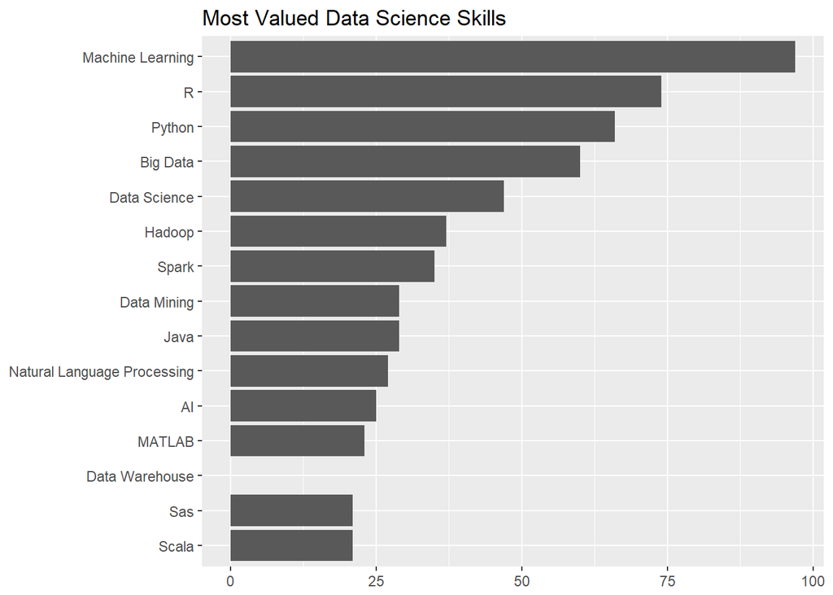

```r
top_15_skills <- dbGetQuery(mydb, "select SkillName, count(*) as n from project3.indeeddatascienceskills
                                  group by SkillName
                                  order by 2 desc
                                  Limit 15;")



library(ggplot2)
ggplot(data=top_15_skills, aes(x=SkillName,y=n)) +
  geom_bar(position="dodge",stat="identity") +
  coord_flip() +
  ggtitle("Most Valued Data Science Skills") +
  scale_x_discrete(
    limits= c("Scala", "Sas", "Data Warehouse", "MATLAB","AI","Natural Language Processing", "Java","Data Mining","Spark",
              "Hadoop", "Data Science", "Big Data", "Python","R", "Machine Learning")
  ) +
theme(
  axis.title.y=element_blank(),
  axis.title.x=element_blank()
  )
```